# Timing matters: Viticultural land use determines responses in structure and function of fungal stream communities across one growing season

##### 3.1.4.3.2 create Figure S8

Plot similar to Figure 2 without ploygons

```r
scl = 'symmetric'
# arrange size of single plot
si_sc <- scores(rda_conid_5, choices = 1:2, scaling = scl, display = 'sites')
sp_sc <- scores(rda_conid_5, choices = 1:2, scaling = scl, display = 'species')
va_sc <- scores(rda_conid_5, choices = 1:2, scaling = scl, display = 'cn')

scrs <- scores(rda_conid_5, display = c("sites"), scaling = scl)

png(filename="Figure_S8_RDA_conidia_wo_polygon.png", width=15, height=15, pointsize=10, units = "cm", res = 800)
p1_RDA_conid <- plot(rda_conid_5,
          scaling = 'symmetric',
          type = 'n',
          xlab =
            paste(attributes(summary(rda_conid_5)$cont$importance)$dimnames[[2]][1],
                     " (", round(summary(rda_conid_5)$cont$importance[2,1]*100),
                     "% total variance)", sep=""),
          ylab =
            paste(attributes(summary(rda_conid_5)$cont$importance)$dimnames[[2]][2],
                     " (", round(summary(rda_conid_5)$cont$importance[2,2]*100),
                     "% total variance)", sep=""),
          xlim = c(min(scrs[,1]), 0.2),
          # at min space added for legend
          ylim = c(min(scrs[,2]) + ((1/10) *  min(scrs[,2])), max(scrs[,2]) + ((1/10) *  max(scrs[,2]))),
          main = NA, cex.lab = 1.5, cex.axis = 1.5, cex.main = 1.5)

# add points colored by fungicide treatment
cols <- c("#19A1BF","#0000EE", "#F00303")
# points shaped by cycle
pchs <- c(16, 17, 15, 18)
points(si_sc,
       col = cols[conid_expl$treatment],  # color by treatment
       pch = pchs[conid_expl$time.point],      # shape by  timepoint
       cex = 1.5)

legend('bottomleft',
       legend = c("forest", "transplant", "viticulture", "April", "June", "August", "September"),
       col = c(rep("white",3), rep('grey20', 4)),
       text.col = c(cols, rep('grey20', 4)),
       pch = c(rep(16, 3), 16, 15, 17, 18), bty = "n", cex=1.3)

dev.off()
```

### 3.1.5 IndVal

identify indicator taxa for time points / treatments

per time point

```r
indval_conid_tp = multipatt(conid_spor, conid_expl$time.point,
                   control = how(nperm=999))

summary(indval_conid_tp, indvalcomp=TRUE)
```

```
##
##  Multilevel pattern analysis
##  ---------------------------
##
##  Association function: IndVal.g
##  Significance level (alpha): 0.05
##
##  Total number of species: 57
##  Selected number of species: 31
##  Number of species associated to 1 group: 22
##  Number of species associated to 2 groups: 6
##  Number of species associated to 3 groups: 3
##
##  List of species associated to each combination:
##
##  Group April  #sps.  14
##                                A      B  stat p.value
## Alatospora.acuminata      0.8613 1.0000 0.928   0.001 ***
## Flagellospora.fusarioides 0.8723 0.9000 0.886   0.001 ***
## Sigmoid_A                 1.0000 0.7667 0.876   0.001 ***
## Filiform_B                0.9947 0.6333 0.794   0.001 ***
## Heliscus.lugdunensis      0.8066 0.7667 0.786   0.001 ***
## Fontanospora.eccentrica   0.9731 0.6333 0.785   0.001 ***
## Lemoniera.terrestris      0.8339 0.7333 0.782   0.001 ***
## Articulospora.tetracladia 0.7309 0.8333 0.780   0.001 ***
## Alatospora.pulchella      1.0000 0.5333 0.730   0.001 ***
## Lemoniera.pseudofloscula  1.0000 0.4333 0.658   0.001 ***
## Unknown_A                 0.8357 0.4667 0.624   0.001 ***
## Unknown_B                 0.8829 0.3667 0.569   0.001 ***
## Filiform_A                1.0000 0.1333 0.365   0.019 *
## Lemoniera.centrosphaera   0.9554 0.1333 0.357   0.041 *
##
##  Group August  #sps.  2
##                           A      B  stat p.value
## Lunulospora.curvula  1.0000 0.3448 0.587   0.001 ***
## Anguillospora.crassa 1.0000 0.1034 0.322   0.041 *
##
##  Group June  #sps.  1
##                A      B  stat p.value
## Unknown_F 1.0000 0.1034 0.322    0.04 *
```

[output cut: 22 more lines]

```
##
##  Group August+June  #sps.  1
##                               A      B  stat p.value
## Tricladium.chaetocladium 0.9640 0.3621 0.591   0.007 **
##
##  Group April+August+September  #sps.  1
##                            A      B  stat p.value
## Anguillospora.furtiva 1.0000 0.3506 0.592   0.001 ***
##
##  Group April+June+September  #sps.  2
##                               A      B  stat p.value
## Anguillospora.longissima 0.9366 0.5325 0.706   0.002 **
## Lemoniera.sp.            1.0000 0.2857 0.535   0.005 **
## ---
## Signif. codes:  0 '***' 0.001 '**' 0.01 '*' 0.05 '.' 0.1 ' ' 1
```

A = specificity or positive predictive value B = fidelity or sensitivity

per treatment

```r
indval_conid_tr = multipatt(conid_spor, conid_expl$treatment,
                   control = how(nperm=999))

summary(indval_conid_tr, indvalcomp=TRUE)
```

```
##
##  Multilevel pattern analysis
##  ---------------------------
##
##  Association function: IndVal.g
##  Significance level (alpha): 0.05
##
##  Total number of species: 57
##  Selected number of species: 5
##  Number of species associated to 1 group: 2
##  Number of species associated to 2 groups: 3
##
##  List of species associated to each combination:
##
##  Group viti  #sps.  2
##                          A      B  stat p.value
## Lunulospora.sp.     0.9437 0.3714 0.592   0.001 ***
## Lunulospora.curvula 0.9538 0.1714 0.404   0.023 *
##
##  Group forest+transplant  #sps.  3
##                                A      B  stat p.value
## Tetrachaetum.elegans      0.9311 0.8169 0.872   0.001 ***
## Articulospora.tetracladia 0.9294 0.5352 0.705   0.001 ***
## Tricladium.chaetocladium  0.9805 0.3099 0.551   0.018 *
## ---
## Signif. codes:  0 '***' 0.001 '**' 0.01 '*' 0.05 '.' 0.1 ' ' 1
```

per streams

```r
indval_conid_s = multipatt(conid_spor, conid_expl$stream,
                   control = how(nperm=999))

summary(indval_conid_s, indvalcomp=TRUE)
```

```
##
##  Multilevel pattern analysis
##  ---------------------------
##
##  Association function: IndVal.g
##  Significance level (alpha): 0.05
##
##  Total number of species: 57
##  Selected number of species: 7
##  Number of species associated to 1 group: 3
##  Number of species associated to 2 groups: 0
##  Number of species associated to 3 groups: 1
##  Number of species associated to 4 groups: 1
##  Number of species associated to 5 groups: 0
##  Number of species associated to 6 groups: 1
##  Number of species associated to 7 groups: 0
##  Number of species associated to 8 groups: 1
##  Number of species associated to 9 groups: 0
##
##  List of species associated to each combination:
##
##  Group Kropsbach  #sps.  3
##                               A      B  stat p.value
## Mycocentrospora.angulata 0.6754 0.5556 0.613   0.024 *
## Lemoniera.centrosphaera  0.9216 0.3333 0.554   0.004 **
## Tricladium.angulatum     0.9030 0.3333 0.549   0.002 **
##
##  Group Dierbach+Otterbach+Russbach  #sps.  1
##                           A      B  stat p.value
## Tricladium.splendens 0.8070 0.3214 0.509   0.013 *
##
##  Group Dierbach+Kropsbach+Russbach+Triefenbach  #sps.  1
##                               A      B  stat p.value
## Tricladium.chaetocladium 0.9517 0.4872 0.681   0.002 **
##
##  Group Kaiserbach+Klingbach+Kropsbach+Modenbach+Otterbach+Triefenbach  #sps.  1
##                                A      B  stat p.value
## Tetracladium.marchalianum 0.8499 0.6716 0.756   0.023 *
##
##  Group Dierbach+Hainbach+Isenach+Kropsbach+Modenbach+Otterbach+Russbach+Triefenbach  #sps.  1
##                           A      B  stat p.value
## Tetrachaetum.elegans 0.9847 0.8171 0.897   0.001 ***
## ---
## Signif. codes:  0 '***' 0.001 '**' 0.01 '*' 0.05 '.' 0.1 ' ' 1
```

### 3.1.6 Turnover / nestedness

to understand changes in the fungal community better, investigate turnover and nestedness use the communities of the forest treatment and April time point as reference

#### 3.1.6.1 calculate turnover

transform dataframe to presence/absence

```r
conid_spor_pa <- conid_spor
conid_spor_pa[conid_spor_pa > 0] <-1
```

According to Baselga (2010) turnover is best calculated using the sorensen distance like this we can identify a turnover (replacement) in taxa

```r
dist_sor <- beta.pair(conid_spor_pa, index.family="sorensen")

turn <- reshape2::melt(as.matrix(dist_sor$beta.sim), varnames = c("row", "col"))
```

get information which row / column is which fungal community

```r
conid_expl_col <- conid_expl

conid_expl_col$code <- rownames(conid_expl_col)
```

since we will compare the different fungal communities to the April forest communities, restrict the column col to these communities The row number of April forest communities are: 1,4,7,10, 13, 16,19,20,25,28

```r
conid_expl_for_April <- conid_expl_col[conid_expl_col$time.point == "April" & conid_expl_col$treatment == "forest", ]

turn2 <- turn[ as.character(turn$col)  %in% conid_expl_for_April$code, ]
```

now connect information about treatment and timepoint to the row column

```r
turn2 <- merge(turn2, conid_expl_col, by.x = c("row"), by.y = c("code"))
```

##### 3.1.6.1.1 create the model

Statistics for the community turnover

```r
turn_lmer1 <- lmer(value ~ time.point + treatment + time.point:treatment + (1|stream), data = turn2)

drop1(turn_lmer1, test = 'Chisq')
```

```
## Single term deletions
##
## Model:
## value ~ time.point + treatment + time.point:treatment + (1 |
##     stream)
##                      npar     AIC   LRT   Pr(Chi)
## <none>                    -1342.2
## time.point:treatment    6 -1304.4 49.71 5.374e-09 ***
## ---
## Signif. codes:  0 '***' 0.001 '**' 0.01 '*' 0.05 '.' 0.1 ' ' 1
```

```r
# interaction highly significant

anova(turn_lmer1)
```

```
## Analysis of Variance Table
##                      npar Sum Sq Mean Sq F value
## time.point              3 4.3094 1.43647 89.6860
## treatment               2 1.0643 0.53216 33.2254
## time.point:treatment    6 0.8079 0.13464  8.4065
```

```r
turn_inter <- lsmeans(turn_lmer1, ~ treatment | time.point )

turn_inter_dunn1 <- contrast(turn_inter, 'pairwise')
(turn_inter_dunn_sum1 <- summary(turn_inter_dunn1, infer = TRUE, adjust = 'mvt'))
```

```
## time.point = April:
##  contrast            estimate     SE   df lower.CL upper.CL t.ratio p.value
##  forest - transplant  -0.0550 0.0179 1039 -0.09698  -0.0130  -3.072  0.0062
##  forest - viti        -0.0801 0.0179 1039 -0.12209  -0.0381  -4.475  <.0001
##  transplant - viti    -0.0251 0.0179 1039 -0.06711   0.0169  -1.403  0.3398
##
## time.point = August:
##  contrast            estimate     SE   df lower.CL upper.CL t.ratio p.value
##  forest - transplant   0.0110 0.0179 1039 -0.03100   0.0530   0.615  0.8121
##  forest - viti        -0.0817 0.0184 1041 -0.12500  -0.0385  -4.434  <.0001
##  transplant - viti    -0.0927 0.0184 1041 -0.13599  -0.0495  -5.031  <.0001
##
## time.point = June:
##  contrast            estimate     SE   df lower.CL upper.CL t.ratio p.value
##  forest - transplant  -0.0595 0.0184 1041 -0.10274  -0.0162  -3.227  0.0037
##  forest - viti        -0.1408 0.0179 1039 -0.18280  -0.0988  -7.866  <.0001
##  transplant - viti    -0.0813 0.0184 1041 -0.12457  -0.0380  -4.411  <.0001
##
## time.point = September:
##  contrast            estimate     SE   df lower.CL upper.CL t.ratio p.value
##  forest - transplant   0.0235 0.0233 1044 -0.03108   0.0781   1.010  0.5707
##  forest - viti         0.0456 0.0233 1044 -0.00897   0.1002   1.961  0.1224
##  transplant - viti     0.0221 0.0231 1039 -0.03211   0.0764   0.957  0.6041
##
## Degrees-of-freedom method: kenward-roger
## Confidence level used: 0.95
## Conf-level adjustment: mvt method for 3 estimates
## P value adjustment: mvt method for 3 tests
```

- In April, transplant and viticulture are similar, but there are differences to the forest treatment
- In June significant differences between all treatments
- In August only forest and transplant show a similarity
- No differences within September

Check differences between treatments across the different time points

```r
turn_inter2 <- lsmeans(turn_lmer1, ~ time.point | treatment)

turn_inter_dunn2 <- contrast(turn_inter2, 'pairwise')
(turn_inter_dunn_sum2 <- summary(turn_inter_dunn2, infer = TRUE, adjust = 'mvt'))
```

```
## treatment = forest:
##  contrast           estimate     SE   df lower.CL upper.CL t.ratio p.value
##  April - August      -0.1210 0.0179 1039  -0.1670 -0.07501  -6.762  <.0001
##  April - June        -0.0868 0.0179 1039  -0.1328 -0.04089  -4.851  <.0001
##  April - September   -0.2622 0.0211 1048  -0.3164 -0.20807 -12.437  <.0001
##  August - June        0.0342 0.0179 1039  -0.0118  0.08018   1.911  0.2227
##  August - September  -0.1412 0.0211 1048  -0.1954 -0.08701  -6.697  <.0001
##  June - September    -0.1754 0.0211 1048  -0.2295 -0.12123  -8.319  <.0001
##
## treatment = transplant:
##  contrast           estimate     SE   df lower.CL upper.CL t.ratio p.value
##  April - August      -0.0550 0.0179 1039  -0.1010 -0.00904  -3.075  0.0114
##  April - June        -0.0913 0.0184 1041  -0.1387 -0.04393  -4.954  <.0001
##  April - September   -0.1837 0.0209 1047  -0.2376 -0.12993  -8.784  <.0001
##  August - June       -0.0363 0.0184 1041  -0.0837  0.01110  -1.968  0.1995
##  August - September  -0.1287 0.0209 1047  -0.1825 -0.07491  -6.153  <.0001
##  June - September    -0.0924 0.0214 1048  -0.1475 -0.03736  -4.311  0.0001
##
## treatment = viti:
##  contrast           estimate     SE   df lower.CL upper.CL t.ratio p.value
##  April - August      -0.1227 0.0184 1041  -0.1701 -0.07525  -6.655  <.0001
##  April - June        -0.1475 0.0179 1039  -0.1935 -0.10151  -8.242  <.0001
##  April - September   -0.1365 0.0209 1047  -0.1903 -0.08272  -6.526  <.0001
##  August - June       -0.0249 0.0184 1041  -0.0722  0.02253  -1.348  0.5306
##  August - September  -0.0138 0.0214 1048  -0.0690  0.04131  -0.646  0.9165
##  June - September     0.0110 0.0209 1047  -0.0428  0.06478   0.526  0.9525
##
## Degrees-of-freedom method: kenward-roger
## Confidence level used: 0.95
## Conf-level adjustment: mvt method for 6 estimates
## P value adjustment: mvt method for 6 tests
```

##### 3.1.6.1.2 create Figure S5 a

create plot of community turnover based on identification of conidia

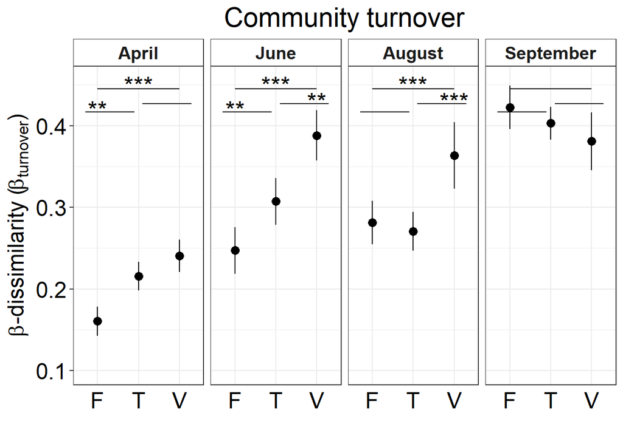

```r
turn_CI <- group.CI(value ~ time.point + treatment,
                   data = turn2,
                   ci = 0.95)

# change order of factor
turn_CI$time.point <- factor(turn_CI$time.point,
                             levels = c("April", "June", "August", "September"))

# rename transplant treatments in order to enable fit to the plot
turn_CI$treatment <- gsub("transplant", "T", turn_CI$treatment)
turn_CI$treatment <- gsub("viti", "V", turn_CI$treatment)
turn_CI$treatment <- gsub("forest", "F", turn_CI$treatment)


# create significance indication
turn_text_1 <- data.frame(treatment = "T", value.mean = 0.45, lab = "***",
                       time.point = factor("April",levels = c("April", "June", "August", "September")))
# Difference forest - viti April
turn_text_2 <- data.frame(treatment = "F", value.mean = 0.42, lab = "**",
                       time.point = factor("April",levels = c("April", "June", "August", "September")))
# Difference forest - transplant April
turn_text_3 <- data.frame(treatment = "T", value.mean = 0.45, lab = "***",
                       time.point = factor("June",levels = c("April", "June", "August", "September")))
# Difference forest - viti June
turn_text_4 <- data.frame(treatment = "F", value.mean = 0.42, lab = "**",
                       time.point = factor("June",levels = c("April", "June", "August", "September")))
# Difference forest - transplant June
turn_text_5 <- data.frame(treatment = "V", value.mean = 0.43, lab = "**",
                       time.point = factor("June",levels = c("April", "June", "August", "September")))
# Difference trans. - viti June
turn_text_6 <- data.frame(treatment = "T", value.mean = 0.45, lab = "***",
                       time.point = factor("August",levels = c("April", "June", "August", "September")))
# Difference forest - viti August
turn_text_7 <- data.frame(treatment = "V", value.mean = 0.43, lab = "***",
                       time.point = factor("August",levels = c("April", "June", "August", "September")))
# Difference trans. - viti August


turn_text <- rbind(turn_text_1, turn_text_2, turn_text_3, turn_text_4, turn_text_5, turn_text_6, turn_text_7)

# lines below significance indication
fv_turn <- data.frame(a = c(1.0, 2, 2, 3), b = rep(c(0.445), 4))
mv_turn <- data.frame(a = c(2.1, 2.5, 3, 3.3), b = rep(c(0.427), 4))
nv_turn <- data.frame(a = c(0.7, 1, 1, 1.9), b = rep(c(0.417), 4))


p1_turn <-  ggplot(turn_CI, aes(x = treatment, y = value.mean)) +
  geom_pointrange(data = turn_CI, aes(y = value.mean, ymin = value.lower, ymax = value.upper))+
  geom_point(data = turn_CI, mapping = aes(y = value.mean), size = 3) +
  facet_wrap(~time.point, nrow = 1) +
  ylab(expression(paste(beta,"-dissimilarity (", beta [turnover],  ")"  ))) +
  xlab("")+
  ggtitle("Community turnover")+
  ylim(0.1, 0.455)+
  geom_text(data = turn_text, label = turn_text$lab, cex = 7) +#, x = taxa_text$treatment, y = taxa_text$DLM.mean) +
  geom_line(data = fv_turn, aes(x = a, y = b)) +
  geom_line(data = mv_turn, aes(x = a, y = b)) +
  geom_line(data = nv_turn, aes(x = a, y = b)) +
  theme_bw()+
  theme(axis.text.x = element_text(size = 18, color="black"), axis.ticks.x = element_blank(),
         axis.text.y = element_text(colour="black", size = 18),
         legend.position="none", strip.text.x = element_text(face = "bold"),
         text = element_text(size=18), plot.title =  element_text(hjust = 0.5),strip.background = element_rect(fill="white"))

p1_turn
```

#### 3.1.6.2 calculate nestedness

nestedness is at best calculated using the sorensen distance like this we can see if communities are subsets of others

```r
dist_sor <- beta.pair(conid_spor_pa, index.family="sorensen")

nest_sor <- reshape2::melt(as.matrix(dist_sor$beta.sne), varnames = c("row", "col"))
```

since we will compare the different fungal communities to the April forest communities, restrict the column col to these communities The rownumber of April forest communities are: 1,4,7,10, 13, 16,19,20,25,28

```r
nest_sor2 <- nest_sor[as.character(nest_sor$col)  %in% conid_expl_for_April$code, ]
```

now connect information about treatment and timepoint to the row column

```r
nest_sor2 <- merge(nest_sor2, conid_expl_col, by.x = c("row"), by.y = c("code"))
```

##### 3.1.6.2.1 create the model

Statistics for the community turnover

```r
nest_lmer1 <- lmer(value ~ time.point + treatment + time.point:treatment + (1|stream), data = nest_sor2)

drop1(nest_lmer1, test = 'Chisq')
```

```
## Single term deletions
##
## Model:
## value ~ time.point + treatment + time.point:treatment + (1 |
##     stream)
##                      npar     AIC    LRT   Pr(Chi)
## <none>                    -1528.5
## time.point:treatment    6 -1445.7 94.773 < 2.2e-16 ***
## ---
## Signif. codes:  0 '***' 0.001 '**' 0.01 '*' 0.05 '.' 0.1 ' ' 1
```

```r
# interaction highly significant

anova(nest_lmer1)
```

```
## Analysis of Variance Table
##                      npar Sum Sq Mean Sq F value
## time.point              3 8.1995 2.73317 204.788
## treatment               2 0.9495 0.47473  35.570
## time.point:treatment    6 1.3105 0.21842  16.365
```

```r
nest_inter <- lsmeans(nest_lmer1, ~ treatment | time.point )

nest_inter_dunn1 <- contrast(nest_inter, 'pairwise')
(nest_inter_dunn_sum1 <- summary(nest_inter_dunn1, infer = TRUE, adjust = 'mvt'))
```

```
## time.point = April:
##  contrast            estimate     SE   df lower.CL upper.CL t.ratio p.value
##  forest - transplant -0.01844 0.0163 1039  -0.0568   0.0199  -1.129  0.4965
##  forest - viti        0.00725 0.0163 1039  -0.0311   0.0456   0.444  0.8970
##  transplant - viti    0.02570 0.0163 1039  -0.0127   0.0640   1.573  0.2579
##
## time.point = August:
##  contrast            estimate     SE   df lower.CL upper.CL t.ratio p.value
##  forest - transplant  0.02136 0.0163 1039  -0.0170   0.0597   1.308  0.3911
##  forest - viti       -0.09614 0.0168 1040  -0.1356  -0.0566  -5.713  <.0001
##  transplant - viti   -0.11750 0.0168 1040  -0.1570  -0.0780  -6.983  <.0001
##
## time.point = June:
##  contrast            estimate     SE   df lower.CL upper.CL t.ratio p.value
##  forest - transplant  0.10965 0.0168 1040   0.0702   0.1491   6.516  <.0001
##  forest - viti        0.01381 0.0163 1039  -0.0245   0.0521   0.845  0.6749
##  transplant - viti   -0.09584 0.0168 1040  -0.1353  -0.0564  -5.695  <.0001
##
## time.point = September:
##  contrast            estimate     SE   df lower.CL upper.CL t.ratio p.value
##  forest - transplant -0.01360 0.0212 1042  -0.0634   0.0362  -0.640  0.7979
##  forest - viti       -0.15068 0.0212 1042  -0.2005  -0.1008  -7.096  <.0001
##  transplant - viti   -0.13708 0.0211 1039  -0.1866  -0.0876  -6.499  <.0001
##
## Degrees-of-freedom method: kenward-roger
## Confidence level used: 0.95
## Conf-level adjustment: mvt method for 3 estimates
## P value adjustment: mvt method for 3 tests
```

- In April no difference –> highly nested
- In June transplant is different from both other treatments, while forest and viti are nested (though taxa richness are similar in all treatments)
- In August no difference between forest and transplant, but low nestedness to the viti treatments
- In September no difference between forest and transplant, but low nestedness to the viti treatments

Check differences between treatments across the different time points

```r
nest_inter2 <- lsmeans(nest_lmer1, ~ time.point | treatment)

nest_inter_dunn2 <- contrast(nest_inter2, 'pairwise')
(nest_inter_dunn_sum2 <- summary(nest_inter_dunn2, infer = TRUE, adjust = 'mvt'))
```

```
## treatment = forest:
##  contrast           estimate     SE   df  lower.CL upper.CL t.ratio p.value
##  April - August      -0.2033 0.0163 1039 -0.245230 -0.16127 -12.441  <.0001
##  April - June        -0.2143 0.0163 1039 -0.256341 -0.17233 -13.119  <.0001
##  April - September   -0.0400 0.0193 1046 -0.089515  0.00961  -2.073  0.1613
##  August - June       -0.0111 0.0163 1039 -0.053086  0.03091  -0.679  0.9046
##  August - September   0.1633 0.0193 1046  0.113793  0.21281   8.474  <.0001
##  June - September     0.1744 0.0193 1046  0.124868  0.22390   9.049  <.0001
##
## treatment = transplant:
##  contrast           estimate     SE   df  lower.CL upper.CL t.ratio p.value
##  April - August      -0.1634 0.0163 1039 -0.205426 -0.12147 -10.004  <.0001
##  April - June        -0.0862 0.0168 1040 -0.129496 -0.04299  -5.125  <.0001
##  April - September   -0.0351 0.0191 1044 -0.084226  0.01401  -1.837  0.2552
##  August - June        0.0772 0.0168 1040  0.033933  0.12047   4.588  <.0001
##  August - September   0.1283 0.0191 1044  0.079239  0.17744   6.715  <.0001
##  June - September     0.0511 0.0196 1046  0.000774  0.10150   2.609  0.0451
##
## treatment = viti:
##  contrast           estimate     SE   df  lower.CL upper.CL t.ratio p.value
##  April - August      -0.3066 0.0168 1040 -0.349870 -0.26342 -18.222  <.0001
##  April - June        -0.2078 0.0163 1039 -0.249734 -0.16583 -12.718  <.0001
##  April - September   -0.1979 0.0191 1044 -0.246996 -0.14877 -10.353  <.0001
##  August - June        0.0989 0.0168 1040  0.055637  0.14209   5.875  <.0001
##  August - September   0.1088 0.0196 1046  0.058406  0.15912   5.550  <.0001
##  June - September     0.0099 0.0191 1044 -0.039180  0.05898   0.518  0.9545
##
## Degrees-of-freedom method: kenward-roger
## Confidence level used: 0.95
## Conf-level adjustment: mvt method for 6 estimates
## P value adjustment: mvt method for 6 tests
```

##### 3.1.6.2.2 create Figure S5 b

create plot of community nestedness based on identification of conidia

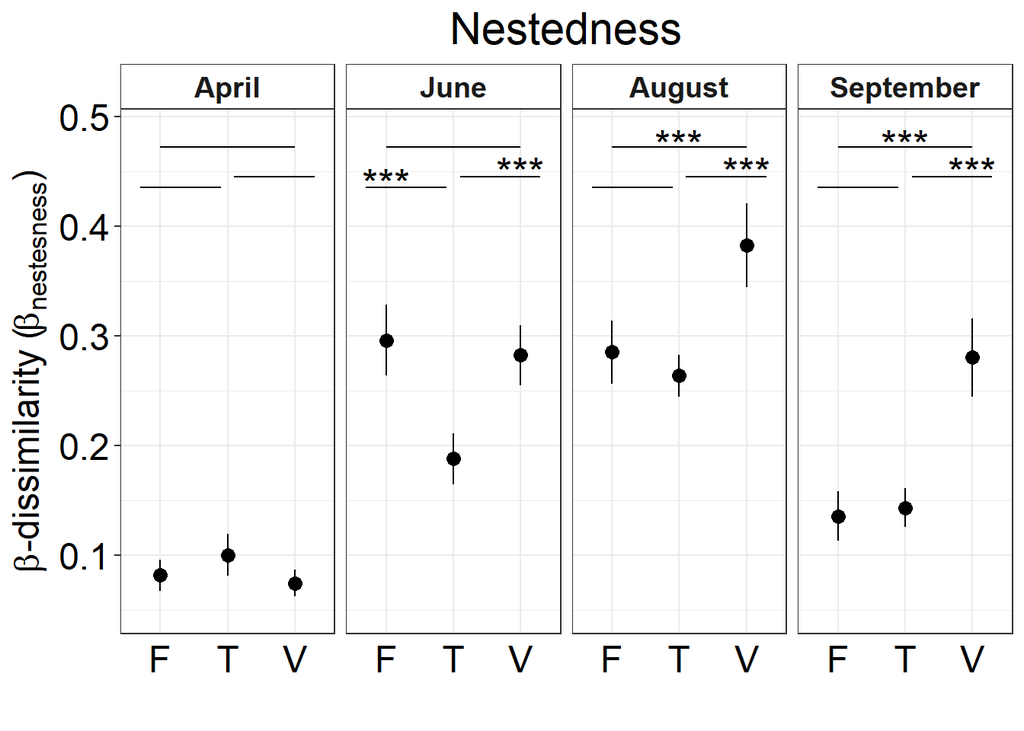

```r
nest_CI <- group.CI(value ~ time.point + treatment,
                   data = nest_sor2,
                   ci = 0.95)

# change order of factor
nest_CI$time.point <- factor(nest_CI$time.point,
                             levels = c("April", "June", "August", "September"))

# rename transplant treatments in order to enable fit to the plot
nest_CI$treatment <- gsub("transplant", "T", nest_CI$treatment)
nest_CI$treatment <- gsub("forest", "F", nest_CI$treatment)
nest_CI$treatment <- gsub("viti", "V", nest_CI$treatment)


# create significance indication
nest_text_1 <- data.frame(treatment = "F", value.mean = 0.44, lab = "***",
                       time.point = factor("June",levels = c("April", "June", "August", "September")))
# Difference forest - transplant June
nest_text_2 <- data.frame(treatment = "V", value.mean = 0.45, lab = "***",
                       time.point = factor("June",levels = c("April", "June", "August", "September")))
# Difference trans. - viti June
nest_text_3 <- data.frame(treatment = "T", value.mean = 0.475, lab = "***",
                       time.point = factor("August",levels = c("April", "June", "August", "September")))
# Difference forest - viti August
nest_text_4 <- data.frame(treatment = "V", value.mean = 0.45, lab = "***",
                       time.point = factor("August",levels = c("April", "June", "August", "September")))
# Difference trans. - viti August
nest_text_5 <- data.frame(treatment = "T", value.mean = 0.475, lab = "***",
                       time.point = factor("September",levels = c("April", "June", "August", "September")))
# Difference forest - viti September
nest_text_6 <- data.frame(treatment = "V", value.mean = 0.45, lab = "***",
                       time.point = factor("September",levels = c("April", "June", "August", "September")))
# Difference trans. - viti September


nest_text <- rbind(nest_text_1, nest_text_2, nest_text_3, nest_text_4, nest_text_5, nest_text_6)

# lines below significance indication
fv_nest <- data.frame(a = c(1.0, 2, 2, 3), b = rep(c(0.472), 4))
mv_nest <- data.frame(a = c(2.1, 2.5, 3, 3.3), b = rep(c(0.445), 4))
nv_nest <- data.frame(a = c(0.7, 1, 1, 1.9), b = rep(c(0.435), 4))


p1_nest <-  ggplot(nest_CI, aes(x = treatment, y = value.mean)) +
  geom_pointrange(data = nest_CI, aes(y = value.mean, ymin = value.lower, ymax = value.upper))+
  geom_point(data = nest_CI, mapping = aes(y = value.mean), size = 3) +
  facet_wrap(~time.point, nrow = 1) +
  ylab(expression(paste(beta,"-dissimilarity (", beta [nestesness],  ")"  ))) +
  xlab("")+
  ggtitle("Nestedness")+
  ylim(0.05, 0.485)+
  geom_text(data = nest_text, label = nest_text$lab, cex = 7) +#, x = taxa_text$treatment, y = taxa_text$DLM.mean) +
  geom_line(data = fv_nest, aes(x = a, y = b)) +
  geom_line(data = mv_nest, aes(x = a, y = b)) +
  geom_line(data = nv_nest, aes(x = a, y = b)) +
  theme_bw()+
  theme(axis.text.x = element_text(size = 18, color="black"), axis.ticks.x = element_blank(),
         axis.text.y = element_text(colour="black", size = 18),
         legend.position="none", strip.text.x = element_text(face = "bold"),
         text = element_text(size=18), plot.title =  element_text(hjust = 0.5),strip.background = element_rect(fill="white"))

p1_nest
```

```r
# unnecessary lines for significance will be removed manually in the vector graphic
```

save plots

```r
fig_S5_beta_diss <-ggarrange(p1_turn, p1_nest, nrow = 2,labels = c("(a)","(b)"))

svg(filename="Figure_S5_beta_diss.svg", width=10, height=15, pointsize=12)
fig_S5_beta_diss
dev.off()
```

## 3.2 Metabarcoding

information retrieved from metabarcoding

See additional R script to create the used data

### 3.2.1 Prepare data

read in data

```r
DNA <- read.table("5_ITS_DataProp.csv", sep=",", header=TRUE, dec=".",  na.string="NA" , check.names=FALSE)
# for creation of this file, see additional R script

DNA$treatment <- as.factor(DNA$treatment)
DNA$timepoint <- as.factor(DNA$timepoint)
DNA$Stream <- as.factor(DNA$Stream)
```

remove coarse data

```r
DNA <- DNA[!DNA$type == "coarse", ]
```

change order of factor + rename treament

```r
DNA$timepoint <- factor(DNA$timepoint,
                             levels = c("April", "June", "August", "September"))
DNA$treatment <- gsub("move", "transplant", DNA$treatment)
DNA$treatment <- gsub("vine", "viti", DNA$treatment)
```

separate explanatory variables from DNA information (for all fungi)

```r
# for all fungi
DNA_fung <- DNA[-c(1:6)]
DNA_expl <- DNA[c(2,3, 5) ]
DNA_expl$treatment <- as.factor(DNA_expl$treatment)
```

reduce the dataset to hyphomycetes

```r
DNA_ASVs <- read.table("6_ITS_Taxonomy_AH.csv", sep=",", header=TRUE, dec=".",  na.string="NA" , check.names=FALSE)
names(DNA_ASVs)[1] <- c("ASV")
DNA_ASVs_hyph <- DNA_ASVs[DNA_ASVs$AQH == "Y", ]

DNA_hyph <- DNA
DNA_hyph <- DNA_hyph[, names(DNA_hyph) %in% DNA_ASVs_hyph$ASV]
# now remove those taxa from the list, which do not occur in the reads list any more
DNA_ASVs_hyph <- DNA_ASVs_hyph[DNA_ASVs_hyph$ASV %in% names(DNA_hyph), ]

DNA_hyph_exp <- cbind(DNA_expl, DNA_hyph)
```

assort ASVs to ITS taxa

```r
DNA_taxa_names <- DNA_ASVs_hyph
DNA_taxa_names <- DNA_taxa_names[,c("Genus", "Species", "ASV")]
DNA_taxa_names$Genus <- gsub("g__", "", DNA_taxa_names$Genus)
DNA_taxa_names$Species <- gsub("s__", "", DNA_taxa_names$Species)
DNA_taxa_names$taxon <- paste(DNA_taxa_names$Genus,DNA_taxa_names$Species)
DNA_taxa_names$taxon <- gsub("NA", "sp.", DNA_taxa_names$taxon)
```

combine the different ASVs which were assigned to the same ITS taxon

```r
DNA_ASV_Single <- DNA_hyph

DNA_taxasumall <- DNA_expl

# separate in taxa which are only assigned to one ASV and to multiple
DNA_taxa_names_count <- dplyr::count(DNA_taxa_names, taxon)
DNA_taxa_names_single <- DNA_taxa_names[!DNA_taxa_names$taxon %in% DNA_taxa_names_count[DNA_taxa_names_count$n > 1,]$taxon, ] # 15 taxa
DNA_taxa_names_multiple <- DNA_taxa_names[DNA_taxa_names$taxon %in% DNA_taxa_names_count[DNA_taxa_names_count$n > 1,]$taxon, ] # 21 taxa

for(i in 1:length(unique(DNA_taxa_names_multiple$taxon))) {

  y <- unique(DNA_taxa_names_multiple$taxon)[i]

DNA_taxasum <- as.data.frame(rowSums(DNA_ASV_Single[, names(DNA_ASV_Single) %in% DNA_taxa_names_multiple[DNA_taxa_names_multiple$taxon == y,]$ASV]) )

names(DNA_taxasum)[1] <- y

DNA_taxasumall <- cbind(DNA_taxasumall, DNA_taxasum)
}

# now add the taxa which are only assigned to one ASV
# filter only for those ASVs
DNA_taxa_single <- DNA_ASV_Single[, names(DNA_ASV_Single) %in% DNA_taxa_names_single$ASV]
# rename all those ASVs (with taxa names)

oldnames = DNA_taxa_names_single$ASV
newnames = DNA_taxa_names_single$taxon

DNA_taxa_single <- DNA_taxa_single %>%
  rename_with(~ newnames[which(all_of(oldnames) == .x)], .cols = oldnames)
# add to other table
DNA_taxasumall <- cbind(DNA_taxasumall, DNA_taxa_single)

rowSums(DNA_taxasumall[4:ncol(DNA_taxasumall)])
```

```
##          1          2          3          4          5          6          7
## 0.75408683 0.18790323 0.21197293 0.16191704 0.52701944 0.37129947 0.23532508
##          8          9         10         11         12         13         14
## 0.18295624 0.04568359 0.10405661 0.40429584 0.15045301 0.42539267 0.24924437
##         15         17         19         22         23         24         25
## 0.25619227 0.32393621 0.42532890 0.61129657 0.62674763 0.57411318 0.66764349
##         29         30         31         32         33         34         35
## 0.38536472 0.52428859 0.35836612 0.50306644 0.32383786 0.47412159 0.90675957
##         36         37         38         39         40         41         42
## 0.17267158 0.26872247 0.43413542 0.10784210 0.36654703 0.27757093 0.26778653
##         43         44         45         46         47         48         49
## 0.12750293 0.06323633 0.19867550 0.33703408 0.52554672 0.03855342 0.43101132
##         50         51         52         53         54         55         56
## 0.57642100 0.40053722 0.58443638 0.55277647 0.52768014 0.65318302 0.21756741
##         57         58         59         60         61         64         65
## 0.55265948 0.46807772 0.25968653 0.75777281 0.87334376 0.68947987 0.04354932
##         68         69         71         72         73         77         80
## 0.30371738 0.54840430 0.87081955 0.83276563 0.15456675 0.88606048 0.26748844
##         82         83         84         85         86         87         88
## 0.95158863 0.94364857 0.29350395 0.71422353 0.67843165 0.27960359 0.23195900
##         89         90         91         92         93         94         95
## 0.55725578 0.38059701 0.46160850 0.34952677 0.27592274 0.46442605 0.36220748
##         96         97         98         99        100        101        102
## 0.19945247 0.24579334 0.13003420 0.24551363 0.09066052 0.27883648 0.52969671
##        103        104        105        106        107        108        109
## 0.17174006 0.12719326 0.24691725 0.25464923 0.30282660 0.15551363 0.15294520
##        110        111        112        113        114        115        116
## 0.03827608 0.22134662 0.08567158 0.48935436 0.17297919 0.11817335 0.14001562
##        117        118        119        120        121        122        123
## 0.43137547 0.12815092 0.29572485 0.02405968 0.43946255 0.17440919 0.11069746
```

### 3.2.2 community composition all fungi

identified via metabarcoding, only on ASV level #### make ANOVAs Create several ANOVAs with different numbers and composition of explanatory variables, to be able to calculate effects sizes and p-values individually for each explanatory variable.

```r
rda_DNA_1 <- rda(decostand(DNA_fung, "hellinger")
                        ~ timepoint +  Condition(Stream), data = DNA_expl)
summary(rda_DNA_1, display = NULL)
```

```
##
## Call:
## rda(formula = decostand(DNA_fung, "hellinger") ~ timepoint +      Condition(Stream), data = DNA_expl)
##
## Partitioning of variance:
##               Inertia Proportion
## Total         0.48606     1.0000
## Conditioned   0.15520     0.3193
## Constrained   0.06261     0.1288
## Unconstrained 0.26826     0.5519
##
## Eigenvalues, and their contribution to the variance
## after removing the contribution of conditiniong variables
##
## Importance of components:
##                         RDA1    RDA2     RDA3     PC1     PC2     PC3     PC4
## Eigenvalue            0.0369 0.02366 0.002048 0.03909 0.03405 0.02198 0.01385
## Proportion Explained  0.1115 0.07151 0.006191 0.11814 0.10292 0.06642 0.04186
## Cumulative Proportion 0.1115 0.18304 0.189227 0.30737 0.41029 0.47672 0.51858
##                           PC5     PC6      PC7      PC8      PC9     PC10
## Eigenvalue            0.01292 0.01009 0.009718 0.008982 0.008209 0.006567
## Proportion Explained  0.03905 0.03051 0.029371 0.027148 0.024811 0.019848
## Cumulative Proportion 0.55763 0.58813 0.617505 0.644653 0.669464 0.689312
##                           PC11     PC12     PC13     PC14     PC15     PC16
## Eigenvalue            0.006301 0.006098 0.005397 0.004911 0.004845 0.004478
## Proportion Explained  0.019043 0.018430 0.016313 0.014844 0.014644 0.013535
## Cumulative Proportion 0.708355 0.726785 0.743098 0.757942 0.772586 0.786121
##                           PC17     PC18     PC19    PC20     PC21     PC22
## Eigenvalue            0.004186 0.003656 0.003642 0.00332 0.003038 0.002772
## Proportion Explained  0.012653 0.011050 0.011006 0.01004 0.009183 0.008378
## Cumulative Proportion 0.798773 0.809823 0.820829 0.83086 0.840048 0.848426
##                           PC23     PC24     PC25     PC26     PC27     PC28
## Eigenvalue            0.002646 0.002526 0.002393 0.002218 0.002098 0.002049
## Proportion Explained  0.007998 0.007635 0.007232 0.006704 0.006340 0.006194
## Cumulative Proportion 0.856425 0.864059 0.871291 0.877995 0.884335 0.890529
##                           PC29     PC30     PC31     PC32     PC33     PC34
## Eigenvalue            0.001977 0.001834 0.001721 0.001671 0.001515 0.001387
## Proportion Explained  0.005975 0.005543 0.005203 0.005051 0.004580 0.004191
## Cumulative Proportion 0.896504 0.902047 0.907249 0.912300 0.916880 0.921071
##                           PC35     PC36     PC37     PC38     PC39      PC40
```

[output cut: 39 more lines]

```
##                            PC86      PC87      PC88      PC89      PC90
## Eigenvalue            0.0001039 0.0001004 9.615e-05 8.645e-05 7.415e-05
## Proportion Explained  0.0003141 0.0003036 2.906e-04 2.613e-04 2.241e-04
## Cumulative Proportion 0.9986460 0.9989495 9.992e-01 9.995e-01 9.997e-01
##                            PC91      PC92
## Eigenvalue            6.325e-05 2.756e-05
## Proportion Explained  1.912e-04 8.331e-05
## Cumulative Proportion 9.999e-01 1.000e+00
##
## Accumulated constrained eigenvalues
## Importance of components:
##                         RDA1    RDA2     RDA3
## Eigenvalue            0.0369 0.02366 0.002048
## Proportion Explained  0.5894 0.37789 0.032717
## Cumulative Proportion 0.5894 0.96728 1.000000
```

```r
anova(rda_DNA_1, by = "margin")
```

```
## Permutation test for rda under reduced model
## Marginal effects of terms
## Permutation: free
## Number of permutations: 999
##
## Model: rda(formula = decostand(DNA_fung, "hellinger") ~ timepoint + Condition(Stream), data = DNA_expl)
##           Df Variance      F Pr(>F)
## timepoint  3 0.062609 7.1573  0.001 ***
## Residual  92 0.268256
## ---
## Signif. codes:  0 '***' 0.001 '**' 0.01 '*' 0.05 '.' 0.1 ' ' 1
```

```r
# timepoint  3 0.062609 7.1573  0.001 ***
# 12.9% explained variance (see at summary, proportion constrained)

rda_DNA_2 <- rda(decostand(DNA_fung, "hellinger")
                        ~ treatment +  Condition(Stream), data = DNA_expl)
summary(rda_DNA_2, display = NULL)
```

```
##
## Call:
## rda(formula = decostand(DNA_fung, "hellinger") ~ treatment +      Condition(Stream), data = DNA_expl)
##
## Partitioning of variance:
##               Inertia Proportion
## Total         0.48606    1.00000
## Conditioned   0.15520    0.31930
## Constrained   0.02068    0.04254
## Unconstrained 0.31019    0.63816
##
## Eigenvalues, and their contribution to the variance
## after removing the contribution of conditiniong variables
##
## Importance of components:
##                          RDA1     RDA2    PC1     PC2     PC3     PC4     PC5
## Eigenvalue            0.01848 0.002203 0.0630 0.03604 0.02583 0.01596 0.01389
## Proportion Explained  0.05584 0.006660 0.1904 0.10894 0.07806 0.04823 0.04197
## Cumulative Proportion 0.05584 0.062501 0.2529 0.36183 0.43989 0.48812 0.53009
##                           PC6      PC7      PC8      PC9     PC10     PC11
## Eigenvalue            0.01082 0.009532 0.009037 0.008649 0.008412 0.007621
## Proportion Explained  0.03269 0.028809 0.027314 0.026140 0.025425 0.023033
## Cumulative Proportion 0.56278 0.591593 0.618907 0.645047 0.670472 0.693505
##                           PC12     PC13     PC14     PC15     PC16     PC17
## Eigenvalue            0.006159 0.005681 0.005405 0.005112 0.004973 0.004606
## Proportion Explained  0.018615 0.017171 0.016335 0.015452 0.015030 0.013922
## Cumulative Proportion 0.712121 0.729291 0.745626 0.761078 0.776107 0.790029
##                          PC18     PC19    PC20     PC21     PC22     PC23
## Eigenvalue            0.00389 0.003742 0.00346 0.003090 0.002946 0.002859
## Proportion Explained  0.01176 0.011311 0.01046 0.009339 0.008905 0.008642
## Cumulative Proportion 0.80179 0.813097 0.82356 0.832894 0.841799 0.850441
##                           PC24     PC25     PC26     PC27     PC28     PC29
## Eigenvalue            0.002710 0.002500 0.002233 0.002222 0.002090 0.002024
## Proportion Explained  0.008191 0.007556 0.006750 0.006715 0.006317 0.006117
## Cumulative Proportion 0.858632 0.866189 0.872939 0.879654 0.885971 0.892088
##                           PC30     PC31     PC32     PC33     PC34     PC35
## Eigenvalue            0.001912 0.001789 0.001707 0.001665 0.001495 0.001284
## Proportion Explained  0.005778 0.005406 0.005161 0.005033 0.004520 0.003881
## Cumulative Proportion 0.897866 0.903271 0.908432 0.913465 0.917985 0.921866
##                           PC36     PC37     PC38     PC39     PC40      PC41
```

[output cut: 39 more lines]

```
##                            PC88      PC89      PC90      PC91      PC92
## Eigenvalue            0.0001072 9.884e-05 8.594e-05 6.606e-05 6.016e-05
## Proportion Explained  0.0003239 2.987e-04 2.597e-04 1.997e-04 1.818e-04
## Cumulative Proportion 0.9989743 9.993e-01 9.995e-01 9.997e-01 9.999e-01
##                            PC93
## Eigenvalue            2.837e-05
## Proportion Explained  8.576e-05
## Cumulative Proportion 1.000e+00
##
## Accumulated constrained eigenvalues
## Importance of components:
##                          RDA1     RDA2
## Eigenvalue            0.01848 0.002203
## Proportion Explained  0.89345 0.106554
## Cumulative Proportion 0.89345 1.000000
```

```r
anova(rda_DNA_2, by = "margin")
```

```
## Permutation test for rda under reduced model
## Marginal effects of terms
## Permutation: free
## Number of permutations: 999
##
## Model: rda(formula = decostand(DNA_fung, "hellinger") ~ treatment + Condition(Stream), data = DNA_expl)
##           Df Variance   F Pr(>F)
## treatment  2 0.020679 3.1  0.001 ***
## Residual  93 0.310185
## ---
## Signif. codes:  0 '***' 0.001 '**' 0.01 '*' 0.05 '.' 0.1 ' ' 1
```

```r
#  treatment  2 0.020679 3.1  0.001 ***
# 4.25 % explained

rda_DNA_3 <- rda(decostand(DNA_fung, "hellinger")
                        ~ timepoint + treatment +  Condition(Stream), data = DNA_expl)
summary(rda_DNA_3, display = NULL)
```

```
##
## Call:
## rda(formula = decostand(DNA_fung, "hellinger") ~ timepoint +      treatment + Condition(Stream), data = DNA_expl)
##
## Partitioning of variance:
##               Inertia Proportion
## Total         0.48606     1.0000
## Conditioned   0.15520     0.3193
## Constrained   0.08348     0.1717
## Unconstrained 0.24739     0.5090
##
## Eigenvalues, and their contribution to the variance
## after removing the contribution of conditiniong variables
##
## Importance of components:
##                          RDA1    RDA2    RDA3     RDA4     RDA5     PC1     PC2
## Eigenvalue            0.03792 0.02395 0.01752 0.002461 0.001627 0.03591 0.02977
## Proportion Explained  0.11461 0.07239 0.05295 0.007438 0.004918 0.10854 0.08998
## Cumulative Proportion 0.11461 0.18700 0.23995 0.247387 0.252305 0.36085 0.45082
##                           PC3     PC4     PC5      PC6      PC7      PC8
## Eigenvalue            0.01654 0.01290 0.01080 0.009602 0.009096 0.008749
## Proportion Explained  0.04999 0.03899 0.03265 0.029022 0.027492 0.026444
## Cumulative Proportion 0.50082 0.53980 0.57245 0.601476 0.628969 0.655412
##                            PC9     PC10     PC11     PC12     PC13     PC14
## Eigenvalue            0.008207 0.006546 0.006239 0.006004 0.005212 0.004829
## Proportion Explained  0.024806 0.019784 0.018857 0.018147 0.015752 0.014595
## Cumulative Proportion 0.680218 0.700002 0.718858 0.737005 0.752757 0.767352
##                           PC15     PC16     PC17     PC18     PC19     PC20
## Eigenvalue            0.004711 0.004287 0.003926 0.003643 0.003387 0.003156
## Proportion Explained  0.014239 0.012957 0.011866 0.011011 0.010236 0.009539
## Cumulative Proportion 0.781591 0.794548 0.806413 0.817425 0.827661 0.837200
##                           PC21     PC22     PC23     PC24     PC25     PC26
## Eigenvalue            0.002903 0.002636 0.002581 0.002380 0.002342 0.002094
## Proportion Explained  0.008774 0.007968 0.007802 0.007193 0.007077 0.006327
## Cumulative Proportion 0.845973 0.853941 0.861743 0.868936 0.876013 0.882341
##                           PC27     PC28     PC29     PC30     PC31     PC32
## Eigenvalue            0.002045 0.001989 0.001914 0.001829 0.001721 0.001600
## Proportion Explained  0.006180 0.006013 0.005786 0.005529 0.005202 0.004835
## Cumulative Proportion 0.888521 0.894534 0.900319 0.905848 0.911050 0.915885
##                           PC33     PC34     PC35     PC36     PC37     PC38
```

[output cut: 39 more lines]

```
##                            PC85      PC86      PC87      PC88      PC89
## Eigenvalue            0.0001085 0.0001020 9.343e-05 8.223e-05 6.756e-05
## Proportion Explained  0.0003279 0.0003084 2.824e-04 2.485e-04 2.042e-04
## Cumulative Proportion 0.9988699 0.9991783 9.995e-01 9.997e-01 9.999e-01
##                            PC90
## Eigenvalue            2.865e-05
## Proportion Explained  8.660e-05
## Cumulative Proportion 1.000e+00
##
## Accumulated constrained eigenvalues
## Importance of components:
##                          RDA1    RDA2    RDA3     RDA4     RDA5
## Eigenvalue            0.03792 0.02395 0.01752 0.002461 0.001627
## Proportion Explained  0.45427 0.28690 0.20986 0.029480 0.019494
## Cumulative Proportion 0.45427 0.74117 0.95103 0.980506 1.000000
```